# HW9_ZhangSherry

Sherry Zhang

4/17/2022

```r
library(ggplot2)  # for plots
library(magrittr)  # for `%>%` operator
library(here)
library(readxl)  # for reading excel files
library(modelsummary)  # for summarizing data
library(rstan)
rstan_options(auto_write = TRUE)  # save compiled STAN object
library(posterior)
library(bayesplot)
library(brms)
library(dplyr)
```

## Research Question

Does the type and polarity of a distractor (mask) affect recognition of a target letter when flashed quickly across a monitor?

## Description of each variable in your preliminary analysis

Contrast: The brightness of the mask, compared to the letters. Ranges from twice as bright to .2 times as bright as the letters. Light-colored masks are on the negative scale, while dark-colored masks were on the positive scale.

Mask type: 1-strip of masking (covers a small portion of the monitor) that does not overlap with the target 0-full field (covers entire monitor) of masking that overlaps with target

Accuracy: Overall accuracy across subjects for each condition.

## Mathematical expressions of your model and priors

Let $C$ = contrast, $M$ = Mask Type

Model:
$$\begin{aligned}
A_i & \sim N(\mu_i, \sigma) \\
\mu_i & = \beta_0+\beta_1C_i+\beta_2M_i+\beta_3C_i\times M_i
\end{aligned}$$

##Your code for running the Bayesian analyses

```r
#reading in data
hw9 <- read_excel(file.choose())
```

```r
hw9$mask <- factor(hw9$mask,
    levels = c(1, 0),
    labels = c("strip", "fullfield")
)
```

Models for different mask types:

```r
m_strip <-
    brm(accuracy ~ contrast,
        data = filter(hw9, mask == "strip"),
        prior = prior(normal(0, 5), class = "b") +
            prior(normal(0, 1), class = "Intercept") +
            prior(student_t(4, 0, 3), class = "sigma"),
        seed = 941,
        iter = 4000
    )
m_fullfield <-
    brm(accuracy ~ contrast,
        data = filter(hw9, mask == "fullfield"),
        prior = prior(normal(0, 5), class = "b") +
            prior(normal(0, 2), class = "Intercept") +
            prior(student_t(4, 0, 3), class = "sigma"),
        seed = 2157,
        iter = 4000
    )
msummary(list(mask = m_strip, `fullfield` = m_fullfield),
         estimate = "{estimate} [{conf.low}, {conf.high}]",
         statistic = NULL, fmt = 2,
         gof_omit = "^(?!Num)"
)
```

|  | mask | fullfield |
| --- | --- | --- |
| b_Intercept | 0.67 [0.57, 0.77] | 0.54 [0.52, 0.56] |
| b_contrast | -0.12 [-0.20, -0.04] | -0.01 [-0.02, 0.01] |
| Num.Obs. | 20 | 20 |

Interaction model:

```r
get_prior(accuracy ~ contrast + mask,
    data = hw9,
    family = gaussian(link = "identity"))
```

```
##                   prior     class          coef group resp dpar nlpar bound
##                  (flat)         b
##                  (flat)         b      contrast
##                  (flat)         b maskfullfield
##  student_t(3, 0.6, 2.5) Intercept
##    student_t(3, 0, 2.5)     sigma
##        source
##       default
##  (vectorized)
##  (vectorized)
##       default
##       default
```

```r
get_prior(accuracy ~ contrast,
    data = hw9,
    family = gaussian(link = "identity"))
```

```
##                   prior     class     coef group resp dpar nlpar bound
##                  (flat)         b
##                  (flat)         b contrast
##  student_t(3, 0.6, 2.5) Intercept
##    student_t(3, 0, 2.5)     sigma
##        source
##       default
##  (vectorized)
##       default
##       default
```

```r
m_int <- brm(
    accuracy ~ mask * contrast,
    data = hw9,
    prior =
        prior(student_t(3, 0.6, 2.5), class = "Intercept") +
        prior(student_t(3, 0, 2.5), class = "sigma"),
    seed = 941,
    iter = 4000
)
m_int
```

```
##  Family: gaussian
##   Links: mu = identity; sigma = identity
## Formula: accuracy ~ mask * contrast
##    Data: hw9 (Number of observations: 40)
##   Draws: 4 chains, each with iter = 4000; warmup = 2000; thin = 1;
##          total post-warmup draws = 8000
##
## Population-Level Effects:
##                        Estimate Est.Error l-95% CI u-95% CI Rhat Bulk_ESS
## Intercept                  0.67      0.03     0.60     0.74 1.00     8578
## maskfullfield             -0.12      0.05    -0.22    -0.03 1.00     8194
## contrast                  -0.12      0.03    -0.17    -0.06 1.00     5368
## maskfullfield:contrast     0.11      0.04     0.03     0.19 1.00     5370
##                        Tail_ESS
## Intercept                  5579
## maskfullfield              5876
## contrast                   5077
## maskfullfield:contrast     4746
##
## Family Specific Parameters:
##       Estimate Est.Error l-95% CI u-95% CI Rhat Bulk_ESS Tail_ESS
## sigma     0.15      0.02     0.12     0.19 1.00     6851     5754
##
## Draws were sampled using sampling(NUTS). For each parameter, Bulk_ESS
## and Tail_ESS are effective sample size measures, and Rhat is the potential
## scale reduction factor on split chains (at convergence, Rhat = 1).
```

##A convergence check of MCMC

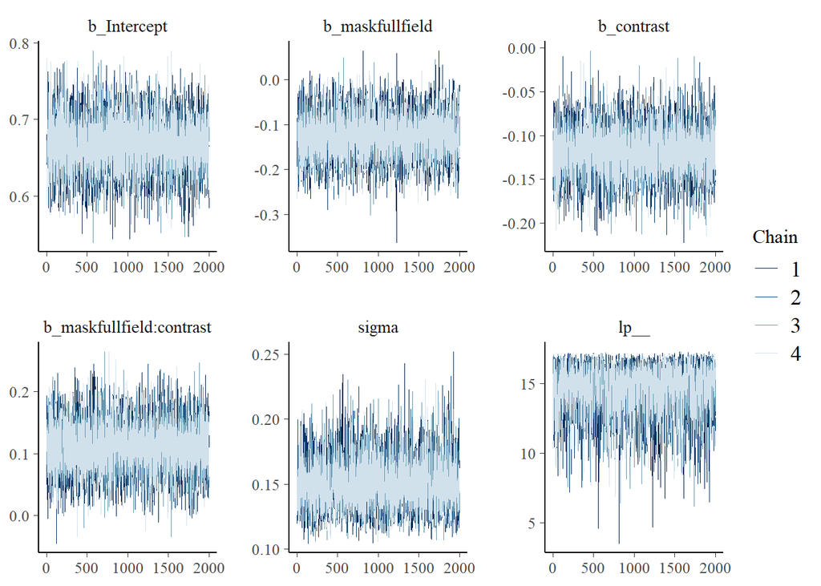

```r
mcmc_trace(m_int)
```

```r
summarize_draws(m_int)
```

```
## # A tibble: 6 x 10
##   variable     mean median     sd    mad      q5     q95  rhat ess_bulk ess_tail
##   <chr>       <dbl>  <dbl>  <dbl>  <dbl>   <dbl>   <dbl> <dbl>    <dbl>    <dbl>
## 1 b_Interce~  0.668  0.667 0.0338 0.0332  0.613   0.723   1.00    8578.    5579.
## 2 b_maskful~ -0.124 -0.125 0.0477 0.0462 -0.202  -0.0441  1.00    8194.    5876.
## 3 b_contrast -0.118 -0.117 0.0279 0.0271 -0.164  -0.0715  1.00    5368.    5077.
## 4 b_maskful~  0.113  0.112 0.0394 0.0385  0.0482  0.177   1.00    5370.    4746.
## 5 sigma       0.151  0.149 0.0185 0.0177  0.124   0.184   1.00    6851.    5754.
## 6 lp__       14.7   15.0   1.71   1.49   11.3    16.8     1.00    3451.    4557.
```

##A table and/or a figure showing the posterior distributions of the key model parameters

```r
summ_m_int <- as_draws_df(m_int) %>%
    summarise_draws()
knitr::kable(summ_m_int, digits = 2)
```

| variable | mean | median | sd | mad | q5 | q95 | rhat | ess_bulk | ess_tail |
| --- | --- | --- | --- | --- | --- | --- | --- | --- | --- |
| b_Intercept | 0.67 | 0.67 | 0.03 | 0.03 | 0.61 | 0.72 | 1 | 8578.39 | 5579.20 |
| b_maskfullfield | -0.12 | -0.12 | 0.05 | 0.05 | -0.20 | -0.04 | 1 | 8193.86 | 5876.09 |
| b_contrast | -0.12 | -0.12 | 0.03 | 0.03 | -0.16 | -0.07 | 1 | 5368.49 | 5076.93 |
| b_maskfullfield:contrast | 0.11 | 0.11 | 0.04 | 0.04 | 0.05 | 0.18 | 1 | 5369.86 | 4746.23 |
| sigma | 0.15 | 0.15 | 0.02 | 0.02 | 0.12 | 0.18 | 1 | 6851.25 | 5753.87 |
| lp__ | 14.66 | 15.03 | 1.71 | 1.49 | 11.31 | 16.75 | 1 | 3450.89 | 4557.45 |

##Interpretation of the results in relation to the research question.

There seems to be a significant effect of mask polarity on recognition only in the strip masking condition, but not in the full-field mask condition.